# R: ggplot2 - First Steps

Jan Malik

24 February 2018

```r
#install.packages("tidyverse") #if needed
```

> About ggplot2
- ggplot2 is a plotting system for R based on the grammar of graphics (as **dplyr** to manipulate data).
- We can find documentation [here](http://ggplot2.org).
- We consider a subsample of the diamond dataset from the package **ggplot2**:

```r
library(tidyverse)
set.seed(1234)
diamonds2 <- diamonds[sample(nrow(diamonds),5000),]
summary(diamonds2)
```

```
     carat               cut       color      clarity         depth           table           price             x              y
 Min.   :0.2000   Fair     : 144   D:640   SI1    :1201   Min.   :54.00   Min.   :51.00   Min.   :  351   Min.   :0.00   Min.   :0.000
 1st Qu.:0.4000   Good     : 427   E:942   VS2    :1131   1st Qu.:61.00   1st Qu.:56.00   1st Qu.:  946   1st Qu.:4.72   1st Qu.:4.730
 Median :0.7000   Very Good:1120   F:874   SI2    : 844   Median :61.80   Median :57.00   Median : 2421   Median :5.70   Median :5.710
 Mean   :0.8024   Premium  :1321   G:989   VS1    : 778   Mean   :61.74   Mean   :57.49   Mean   : 3992   Mean   :5.74   Mean   :5.742
 3rd Qu.:1.0500   Ideal    :1988   H:790   VVS2   : 460   3rd Qu.:62.50   3rd Qu.:59.00   3rd Qu.: 5405   3rd Qu.:6.55   3rd Qu.:6.540
 Max.   :3.2200                    I:532   VVS1   : 336   Max.   :78.20   Max.   :79.00   Max.   :18779   Max.   :9.49   Max.   :9.420
                                   J:233   (Other): 250
       z
 Min.   :0.000
 1st Qu.:2.910
 Median :3.530
 Mean   :3.543
 3rd Qu.:4.040
 Max.   :5.920
```

```r
#help(diamonds)
```

Given a dataset, a ggplot graph is defined from many **layers**. We have to specify:

- the data
- the variables we want to plot
- the type of representation (scatterplot, boxplot…).

Ggplot graphs are defined from these layers. We indicate:

- the data with **ggplot**
- the variables with **aes** (aesthetics)
- the type of representation with **geom_**

The scatterplot **carat vs price** is obtained with the **plot** function with

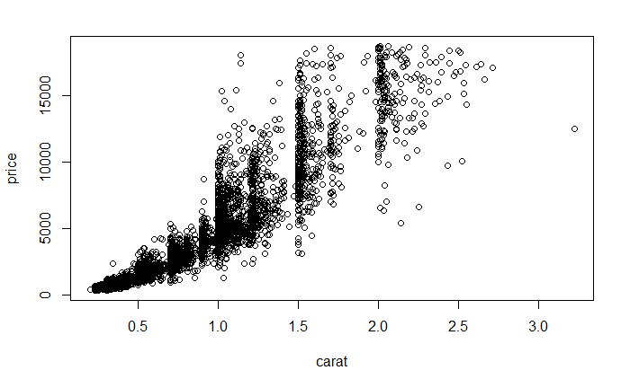

```r
plot(price~carat,data=diamonds2)
```

With **ggplot**, we use

```r
#ggplot(diamonds2) #nothing
#ggplot(diamonds2)+aes(x=carat,y=price) #aesthetic with nothing
ggplot(diamonds2)+aes(x=carat,y=price)+geom_point() #good
```

[output not shown]

# 1 Different ‘geom_’ types

- Draw the histogram of **carat** (use **geom_histogram**)
- Draw the histogram of **carat** with 10 bins (**help(geom_histogram)**)
- Draw the barplot for the variable **cut** (use **geom_bar**)

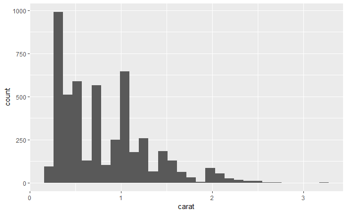

```r
ggplot(diamonds2)+aes(x=carat)+geom_histogram() #using 'bins=30' by default
```

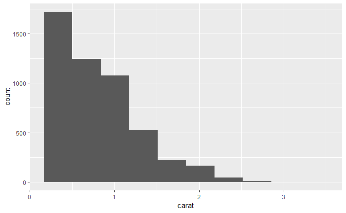

```r
#help(geom_histogram)
ggplot(diamonds2)+aes(x=carat)+geom_histogram(bins=10)
```

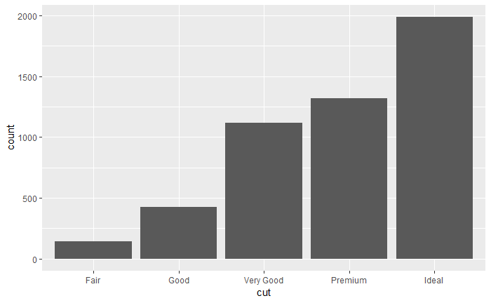

```r
ggplot(diamonds2)+aes(x=cut)+geom_bar()
```

## 1.1 Ggplot grammar

In ggplot, the syntax is defined from independent elements. These elements define the **grammar** of **ggplot**. Main elements of the grammar include:

- **Data (ggplot)**: the dataset, it should be a dataframe
- **Aesthetics (aes)**: to describe the way that variables in the data are mapped. All the variables used in the graph should be precise in **aes**
- **Geometrics (geom_…)**: to control the type of plot
- **Statistics (stat_…)**: to describe transformation of the data
- **Scales (scale_…)**: to control the mapping (configuration) from data to aesthetic attributes (change of colors…)

All these elements are combined with a **+**.

### 1.1.1 `Data and aesthetics`

These two elements specify the data and the variables we want to represent.

**aes** also uses arguments such as **color**, **size**, **fill**. We use these arguments as soon as a color or a size is defined from a **variable of the dataset**.

### 1.1.2 `Geometrics`

To obtain the graph, we need to precise the type of representation. We use **geometrics** to do that. For a scatter plot, we use **geom_point**:

```r
ggplot(diamonds2)+aes(x=carat,y=price,color=cut)+geom_point()
```

[output not shown]

| Geom | Description | Aesthetics |
| --- | --- | --- |
| geom_point() | Scatter plot | x, y, shape, fill |
| geom_line() | Line (ordered according to x) | x, y, linetype |
| geom_abline() | Line | slope, intercept |
| geom_path() | Line (ordered according to the index) | x, y, linetype |
| geom_text() | Text | x, y, label, hjust, vjust |
| geom_rect() | Rectangle | xmin, xmax, ymin, ymax, fill, linetype |
| geom_polygon() | Polygone | x, y, fill, linetype |
| geom_segment() | Segment | x, y, fill, linetype |
| geom_bar() | Barplot | x, fill, linetype, weight |
| geom_histogram() | Histogram | x, fill, linetype, weight |
| geom_boxplot() | Boxplots | x, y, fill, weight |
| geom_density() | Density | x, y, fill, linetype |
| geom_contour() | Contour lines | x, y, fill, linetype |
| geom_smooth() | Smoothers (linear or non linear) | x, y, fill, linetype |
| All |  | color, size, group |

> Other example
- Drawing the barplot of **cut** with default blue bars.
- Dranwing the barplot of **cut** with a Hex color code of your choice.
- Drawing the barplot of **cut** with one color for each modality of cut.

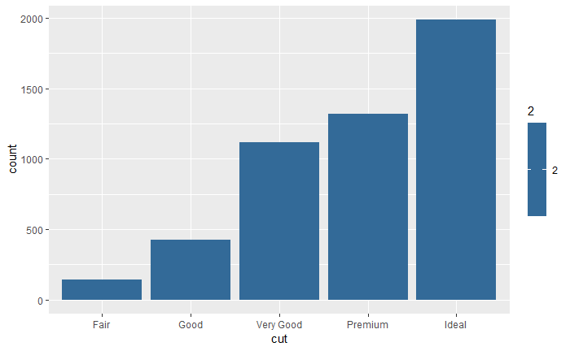

```r
ggplot(diamonds2)+aes(x=cut,fill=2)+geom_bar()
```

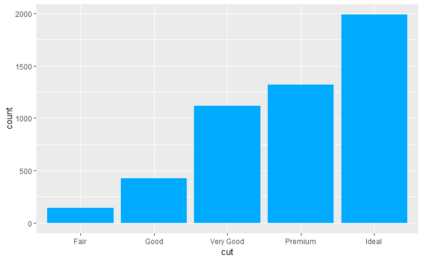

```r
ggplot(diamonds2)+aes(x=cut)+geom_bar(fill="#00abff")
```

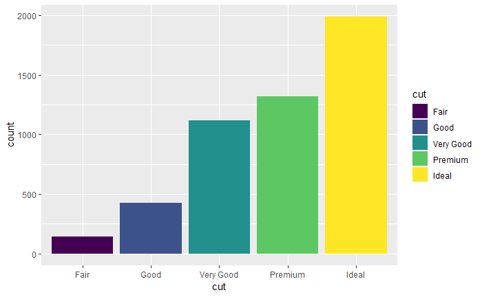

```r
ggplot(diamonds2)+aes(x=cut,fill=cut)+geom_bar()
```

### 1.1.3 `Statistics`

Many graphs need to transform the data to make the representation (barplot, histogram). Simple transformations can be obtained quickly. For instance we can draw the sine function/wave with:

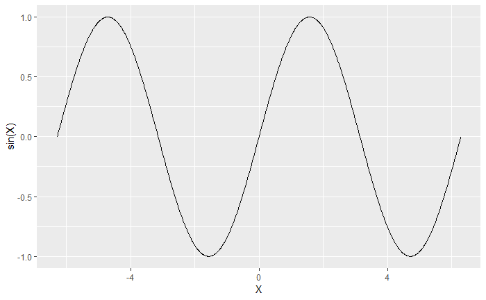

```r
D <- data.frame(X=seq(-2*pi,2*pi,by=0.01))
ggplot(D)+aes(x=X,y=sin(X))+geom_line()
```

The sine transformation is precised in **aes**. For more complex transformations, we have to used **statistics**. A **stat** function takes a dataset as input and returns a dataset as output, and so a stat can add new variables to the original dataset. It is possible to map aesthetics to these new variables. For example, **stat_bin**, the statistic used to make histograms, produces the following variables:

- `count`, the number of observations in each bin
- `density`, the density of observations in each bin (percentage of total / bar width)
- `x`, the center of the bin

By default *geom_histogram* represents on the $y$-axis the number of observations in each bin (the outuput **count**).

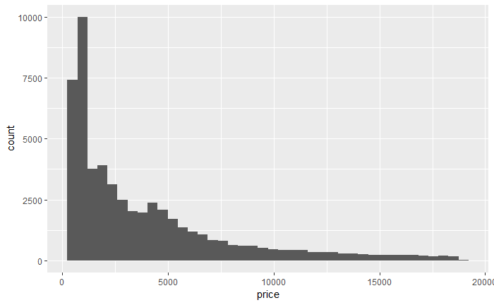

```r
ggplot(diamonds)+aes(x=price)+geom_histogram(bins=40)
```

For the density, we use

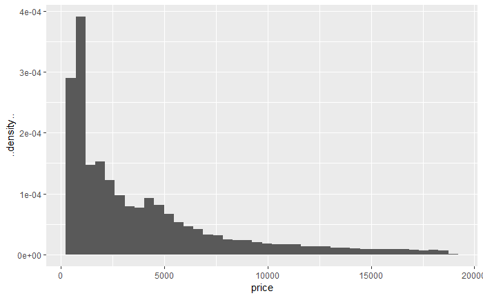

```r
ggplot(diamonds)+aes(x=price,y=..density..)+geom_histogram(bins=40)
```

## 1.2 Add on methods

*ggplot* proposes another way to make the representations: we can use *stat_* instead of *geom_*. Formally, each stat function has a geom and each geom has a stat. For instance,

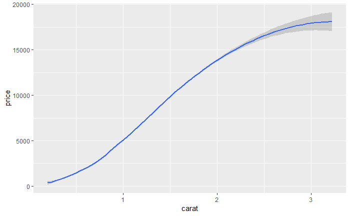

```r
ggplot(diamonds2)+aes(x=carat,y=price)+geom_smooth(method="loess")
```

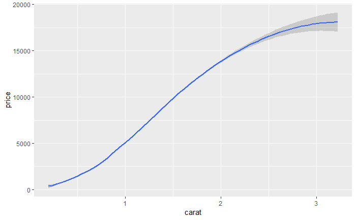

```r
ggplot(diamonds2)+aes(x=carat,y=price)+stat_smooth(method="loess")
```

lead to the same graph. We can change the type of representation in the **stat_** with the argument **geom**:

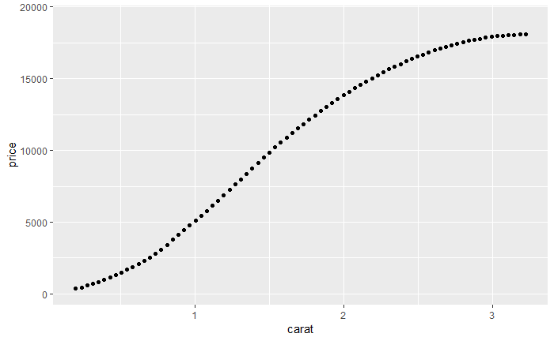

```r
ggplot(diamonds2)+aes(x=carat,y=price)+stat_smooth(method="loess",geom="point")
```

Here are some examples of **stat functions**

| Stat | Description | Parameters |
| --- | --- | --- |
| stat_identity() | No transformation |  |
| stat_bin() | Count | binwidth, origin |
| stat_density() | Density | adjust, kernel |
| stat_smooth() | Smoother | method, se |
| stat_boxplot() | Boxplot | coef |

*stat* and *geom* are not always easy to combine. For beginners, we recommand to only use *geom*.

# 2 Managing colors and facets

We consider a color variable $X$ with probability distribution
$$P(X=red)=0.3,\ P(X=blue)=0.2,\ P(X=green)=0.4,\ P(X=black)=0.1$$
Drawing the barplot of this distribution:

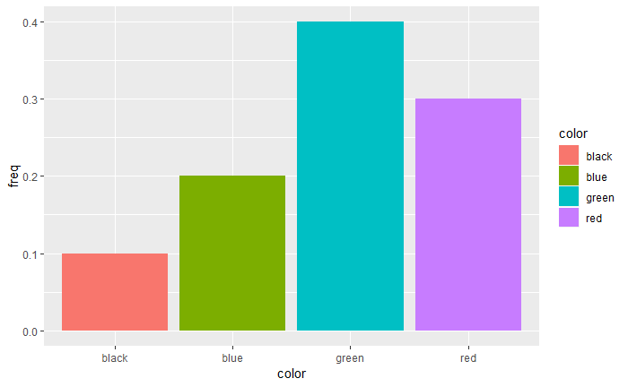

```r
data<- data.frame(color=c("red","blue","green","black"),freq=c(0.3,0.2,0.4,0.1))
ggplot(data)+aes(x=color,y=freq,fill=color)+geom_bar(stat="identity")
```

## 2.1 `Scales`

Scales control the mapping from data to aesthetic attributes (change of colors, sizes…). We generally use this element at the end of the process to refine the graph. Scales are defined as follows:

- begin with **scale_**
- add the aesthetics we want to modify (**color**, **fill**, **x_**)
- end with the name of the scale (**manual**, **identity**…)

For instance,

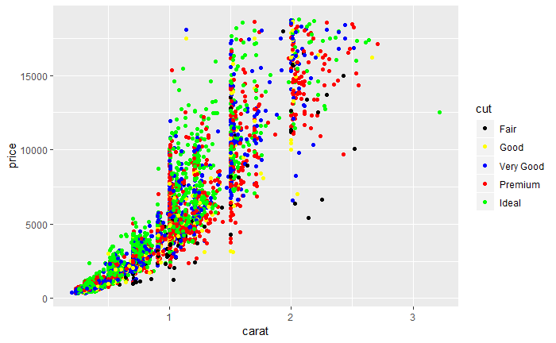

```r
ggplot(diamonds2)+aes(x=carat,y=price,color=cut)+geom_point()+
scale_color_manual(values=c("Fair"="black",
                            "Good"="yellow",
                            "Very Good"="blue",
                            "Premium"="red",
                            "Ideal"="green"))
```

Here are the main scales:

| aes | Discrete | Continuous |
| --- | --- | --- |
| Couleur (color et fill) | brewer | gradient |
| - | grey | gradient2 |
| - | hue | gradientn |
| - | identity |  |
| - | manual |  |
| Position (x et y) | discrete | continous |
| - |  | date |
| Forme | shape |  |
| - | identity |  |
| - | manual |  |
| Taille | identity | size |
| - | manual |  |

## 2.2 Some examples:

### 2.2.1 `Color of a barplot`

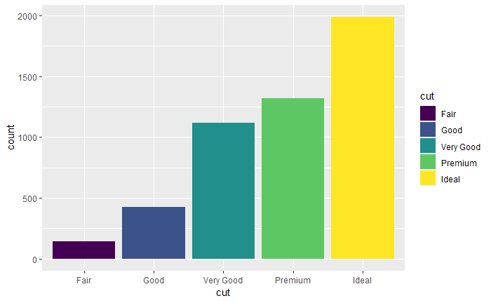

```r
p1 <- ggplot(diamonds2)+aes(x=cut)+geom_bar(aes(fill=cut))
p1
```

We change colors by using the palette **Purples** :

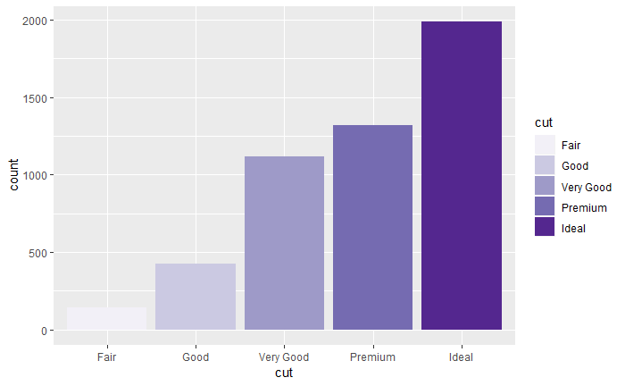

```r
p1+scale_fill_brewer(palette="Purples")
```

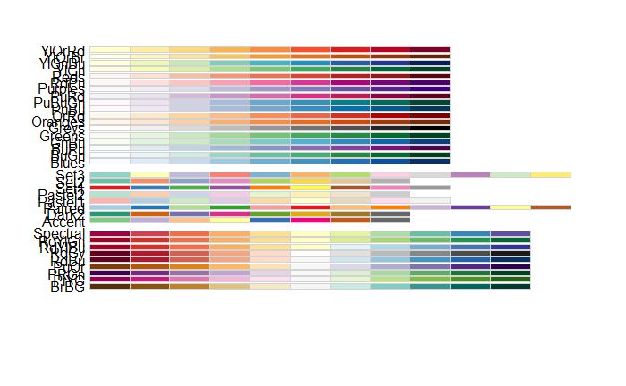

```r
RColorBrewer::display.brewer.all()
```

### 2.2.2 `Coord_flip()`

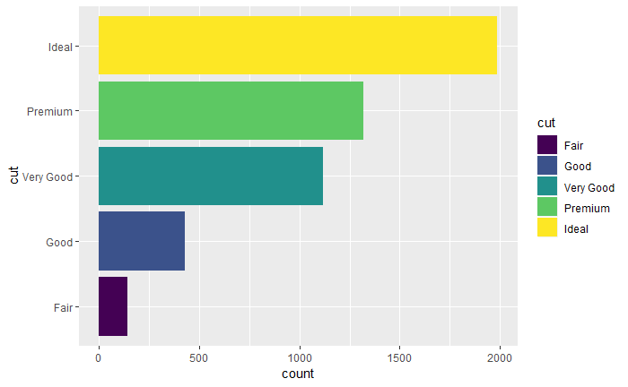

```r
p1 + coord_flip()
```

### 2.2.3 `Gradient color for a scatter plot` :

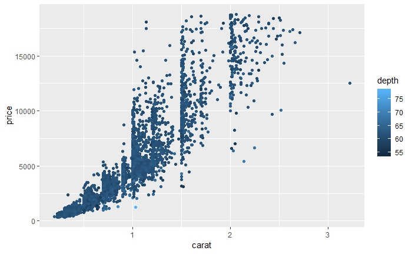

```r
p2 <- ggplot(diamonds2)+aes(x=carat,y=price)+geom_point(aes(color=depth))
p2
```

We change the gradient color

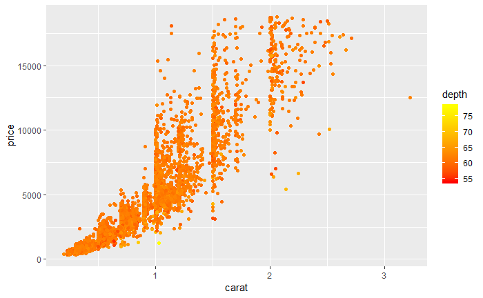

```r
p2+scale_color_gradient(low="red",high="yellow")
```

### 2.2.4 `Change on the axis`

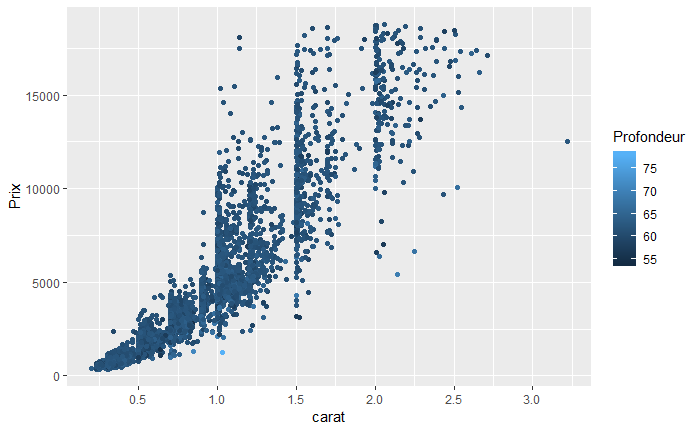

```r
p2+scale_x_continuous(breaks=seq(0.5,3,by=0.5))+scale_y_continuous(name="Prix")+scale_color_gradient("Profondeur")
```

## 2.3 `Group and facets`

**ggplot** allows to make representations for subgroup of individuals. We can proceed in two ways:

- to represent subgroup on the same graph, we use *group* in **aes**
- to represent subgroup on the different graphs, we use **facets**

We can represent (on the same graph) the smoother **price vs carat** for each modality of *cut* with

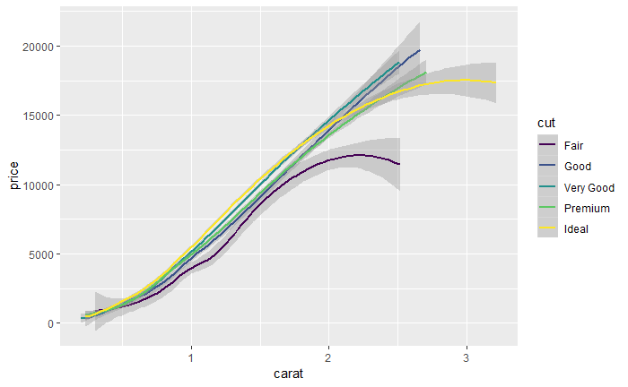

```r
ggplot(diamonds2)+aes(x=carat,y=price,group=cut,color=cut)+geom_smooth(method="loess")
```

To obtain the representation on many graphs, we use

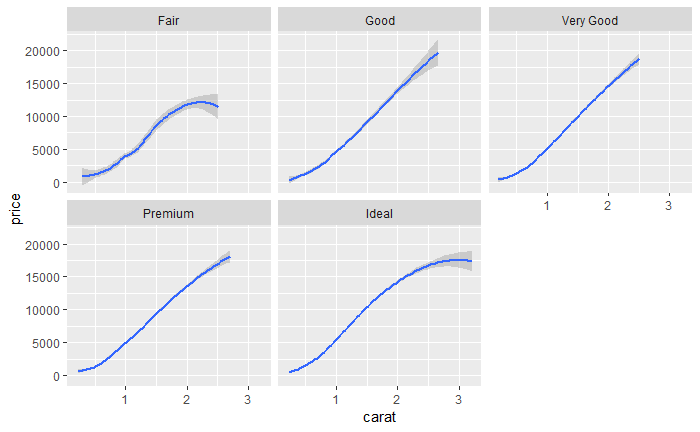

```r
ggplot(diamonds2)+aes(x=carat,y=price)+geom_smooth(method="loess")+facet_wrap(~cut)
```

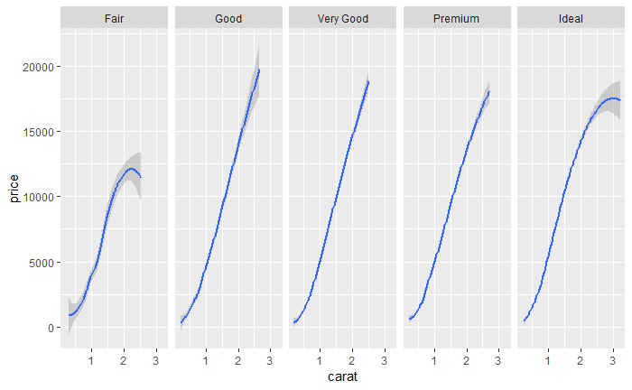

```r
ggplot(diamonds2)+aes(x=carat,y=price)+geom_smooth(method="loess")+facet_wrap(~cut,nrow=1)
```

*facet_grid* and *facet_wrap* do the same job but split the screen in different ways:

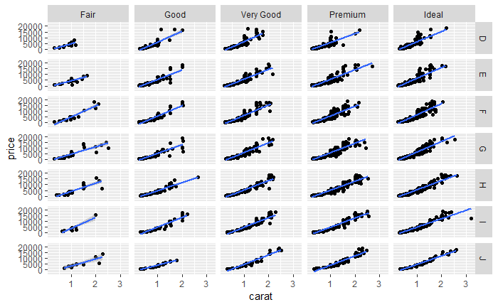

```r
ggplot(diamonds2)+aes(x=carat,y=price)+geom_point()+geom_smooth(method="lm")+facet_grid(color~cut)
```

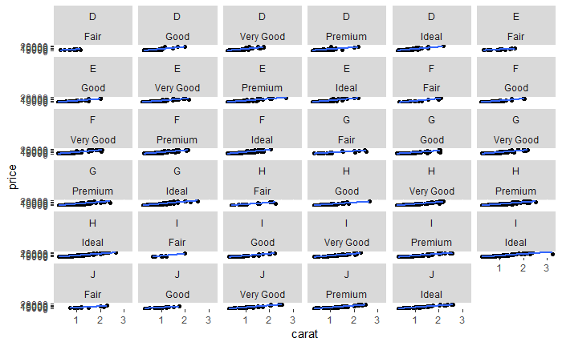

```r
ggplot(diamonds2)+aes(x=carat,y=price)+geom_point()+geom_smooth(method="lm")+facet_wrap(color~cut)
```

# 3 Furthermore

## 3.1 Syntax flexibility

Syntax for **ggplot** is defined according to the following scheme:

`ggplot()+aes()+geom_()+scale_()`

It is really flexible: for instance **aes** could also be specified in **ggplot** or in **geom_**

```r
ggplot(diamonds2)+aes(x=carat,y=price)+geom_point()
```

```r
ggplot(diamonds2,aes(x=carat,y=price))+geom_point()
```

```r
ggplot(diamonds2)+geom_point(aes(x=carat,y=price))
```

## 3.2 Multiple geom_ on the same graph

[figure not shown]

```r
X <- seq(-2*pi,2*pi,by=0.01)
Y <- sin(X)
sinus <- data.frame(X=X,Y=Y)
g <- ggplot(sinus,aes(X,Y))+geom_line()
#g+geom_hline(yintercept=1)+geom_hline(yintercept=-1)
#g+geom_hline(yintercept=1,aes(colour='#990000'))+geom_hline(yintercept=-1)
g+geom_hline(yintercept=1,color="blue")+geom_hline(yintercept=-1,color="blue")
```

## 3.3 Use multiple datasets

We can also built a graph with many datasets:

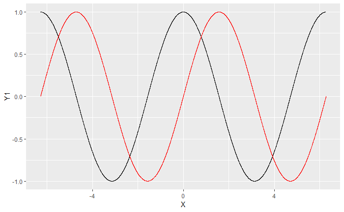

```r
X <- seq(-2*pi,2*pi,by=0.001)
Y1 <- cos(X)
Y2 <- sin(X)
donnees1 <- data.frame(X,Y1)
donnees2 <- data.frame(X,Y2)
ggplot(donnees1)+geom_line(aes(x=X,y=Y1))+geom_line(data=donnees2,aes(x=X,y=Y2),color="red")
```

Or use the *gather()* function

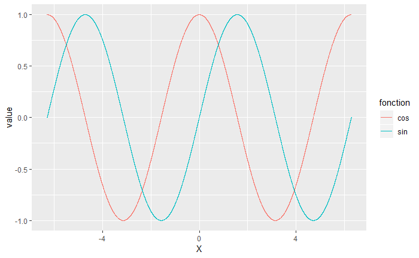

```r
X <- seq(-2*pi,2*pi,by=0.001)
Y1 <- cos(X)
Y2 <- sin(X)
data <- data.frame(X,cos=Y1,sin=Y2)
new_data <- gather(data=data,key="fonction",values=c(cos,sin))
#new_data <- gather(data=data,key="func",values="value",-X)   also works!
ggplot(new_data)+aes(x=X,y=value,colour=fonction)+geom_line()
```

## 3.4 Adapt your graph facets

Drawing those two functions on two different graphs (use **facet_wrap**).

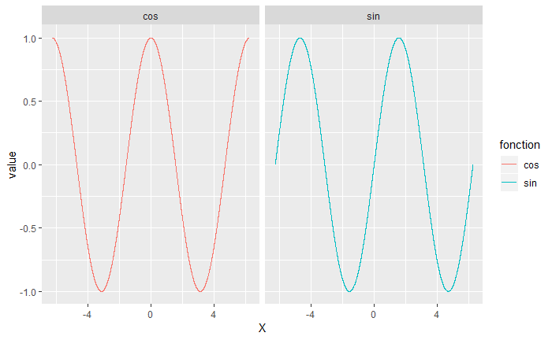

```r
ggplot(new_data)+aes(x=X,y=value,colour=fonction)+geom_line()+facet_wrap(~fonction)
```

```r
#ggplot(new_data)+aes(x=X,y=value)+geom_line()+facet_wrap(~fonction)
```

We can also do the same with the function **grid.arrange** from the package **gridExtra**.

```r
#install.packages("gridExtra") #if needed
library(gridExtra)
```

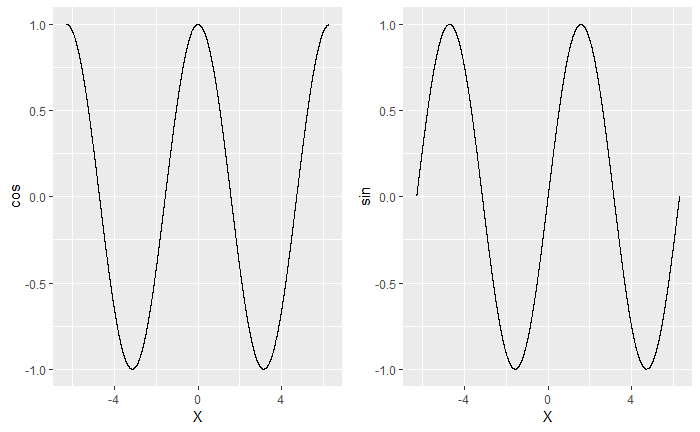

```r
X <- seq(-2*pi,2*pi,by=0.001)
Y1 <- cos(X)
Y2 <- sin(X)
data1 <- data.frame(X,cos=Y1)
data2 <- data.frame(X,sin=Y2)
g1 <- ggplot(data1)+geom_line(aes(x=X,y=cos))
g2 <- ggplot(data2)+geom_line(aes(x=X,y=sin))
grid.arrange(g1,g2,ncol=2)
```